# Stochastic Processes: Vasicek Model & Brownian Motion

## Geometric Brownian Motion

### Using sapply

#### sapply code

```r
sapply_gbm <- function(n, T, r, sigma, S.1, seed.num = NULL){

  #safe-check................
  if (!is.null(seed.num)) {
    set.seed(seed.num)
  }
  #setup......................
  n <- n
  T <- T
  df <- data.frame(index = seq(1, n+1))
  # 1st step
  t <- c(0, sort(runif(n, min = 0, max = T)))
  W <- numeric(n + 1)
  W[1] <- 0
  S <- numeric(n + 1)
  S[1] <- S.1
  # 2nd step
  Z <- rnorm(n)

  #..............................
  # 3rd step
  S <- c(S.1,sapply(2:(n+1), function(i){
    S[i] <<- S[i-1]*exp((r - 0.5*sigma^2)*(t[i] - t[i-1]) +
                          sigma*sqrt(t[i] - t[i-1])*Z[i-1])
  }
  ))

  df["S"] <- S
  df["W"] <- W
  df["t"] <- t

  # 4th step
  p <- ggplot(data = df, aes(x = t, y = S)) +
    geom_step() +
    labs(
      title = "Geometric Brownian motion path simulation (sapply)",
      x = "Time (years)",
      y = "Stock price"
    )

  output <- list(n = n, T = T, df = df, t = t, W = W, Z = Z, S = S, p = p)
  return(output)

}
```

#### sapply sample

```r
sapply_gbm(n = 10,T = 1,r = 0.1,sigma = 2,S.1 = 10,seed.num = 2024)
```

$n [1] 10

$T [1] 1

$df index S W t 1 1 10.0000000 0 0.0000000 2 2 19.4569692 0 0.1190482 3 3 21.6970491 0 0.3032091 4 4 20.2846267 0 0.3208675 5 5 7.9662921 0 0.4157110 6 6 4.6692167 0 0.4570092 7 7 0.6289542 0 0.6803633 8 8 0.6890936 0 0.6981731 9 9 0.7529890 0 0.7014203 10 10 0.7221988 0 0.8369425 11 11 0.1818306 0 0.8765881

$t [1] 0.0000000 0.1190482 0.3032091 0.3208675 0.4157110 0.4570092 0.6803633 [8] 0.6981731 0.7014203 0.8369425 0.8765881

$W [1] 0 0 0 0 0 0 0 0 0 0 0

$Z [1] 1.2923548 0.5346471 -0.1270347 -1.2248754 -1.1213513 -1.6719250 [7] 0.4689179 0.8321899 0.2930216 -3.2742858

$S [1] 10.0000000 19.4569692 21.6970491 20.2846267 7.9662921 4.6692167 [7] 0.6289542 0.6890936 0.7529890 0.7221988 0.1818306

$p

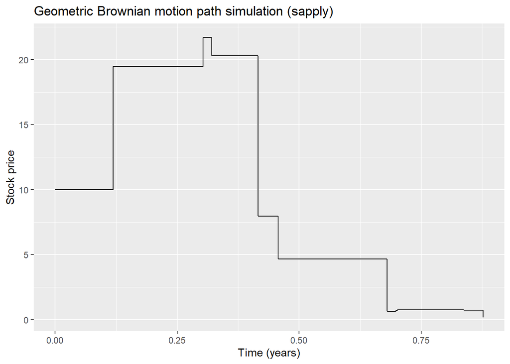

### Using matrix

#### matrix code

```r
sapply_gbm_mtx <- function(m, n, T, r, sigma, S.1, seed.num = NULL){
  #safe-check................
  if (!is.null(seed.num)) {
    set.seed(seed.num)
  }
  #setup......................
  n <- n
  T <- T
  r <- r
  sigma <- sigma
  # 1st step
  t <- c(0, sort(runif(n, min = 0, max = T)))
  S <- matrix(numeric(), nrow = m, ncol = n + 1)
  S[,1] <- S.1
  # 2nd step
  Z <- matrix(rnorm(m * n), nrow = m, ncol = n)

  #..............................
  # Simulate Brownian motion using a for loop
  sapply(2:(n + 1), function(i) {
    S[,i] <<- S[,i-1]*exp((r - 0.5*sigma^2)*(t[i] - t[i-1]) +
                            sigma*sqrt(t[i] - t[i-1])*Z[,i-1])

  })
  #add w to the dataframe
  df <- as.data.frame(S) |>
    setNames(t) |>
    mutate(Path = row_number()) |>
    pivot_longer(cols = -Path, names_to = "Time", values_to = "S")

  # 4th step
  p <- ggplot(df, aes(x = Time, y = S, group = Path, color = factor(Path))) +
    geom_line(alpha = 0.5) +
    labs(x = "Time", y = "dW", title = "Brownian Motion", color = "Path Number") +
    theme_minimal()

  output <- list(n = n, T = T, df = df, t = t, Z = Z, p = p)
  return(output)
}
```

#### matrix sample

```r
sapply_gbm_mtx(m = 10, n = 12,T = 1,r = 0.1,sigma = 2,S.1 = 10)
```

$n [1] 12

$T [1] 1

$df # A tibble: 130 × 3 Path Time S 1 1 0 10  
2 1 0.0221378488931805 10.5 3 1 0.0541251725517213 8.82 4 1 0.176201401976869 6.97 5 1 0.290289726341143 3.35 6 1 0.441127684665844 4.90 7 1 0.647367488825694 1.11 8 1 0.67516271979548 1.46 9 1 0.68095475086011 1.33 10 1 0.872851980151609 1.36 # ℹ 120 more rows

$t [1] 0.00000000 0.02213785 0.05412517 0.17620140 0.29028973 0.44112768 [7] 0.64736749 0.67516272 0.68095475 0.87285198 0.91045726 0.96611989 [13] 0.97337945

$Z [,1] [,2] [,3] [,4] [,5] [,6] [1,] 0.3157030 -0.3253350 -0.004691013 -0.76571106 0.8601974 -1.20821528 [2,] 1.0426861 -0.5052809 0.495375149 -0.64669436 0.5383698 0.29586592 [3,] -0.2129825 1.2042490 1.972818679 -1.02753085 0.1752457 0.07526869 [4,] 0.3971004 -0.4989789 -1.196862124 -0.68089807 1.6458981 0.19616025 [5,] -1.5436525 0.3895955 0.130438481 -1.43361066 -0.1288879 -0.31275890 [6,] -0.1181997 0.3373319 0.329059640 0.89549351 -1.9955040 1.42129015 [7,] 0.6846979 -0.4892616 0.668158302 -0.23906127 0.7146394 0.68347055 [8,] -2.0557223 -0.5707711 0.638992957 1.00040381 0.4916996 -1.03885629 [9,] -0.1094240 0.4283641 1.940451296 -0.03258998 -2.1188126 0.01568269 [10,] -1.4397936 -0.8724618 -0.554539065 1.59294708 1.1313185 -1.24320968 [,7] [,8] [,9] [,10] [,11] [,12] [1,] 0.9918590 -0.52123011 0.4401328 1.12481194 -0.32856747 0.13351857 [2,] 0.8639651 -0.70471245 1.0431660 -0.70100073 -1.30367636 -0.64971648 [3,] -1.7550385 0.68743747 0.1256767 -0.02887581 -0.19728944 0.03673065 [4,] 0.1488082 0.54759290 -1.2652495 -0.62497489 -0.71144006 1.69080706 [5,] 1.1100746 -2.06585280 0.3743600 -1.83036802 0.02884138 -0.84300123 [6,] -0.1827529 -1.16581875 -0.1996094 1.90479317 -1.07349486 -1.20077212 [7,] -0.2551878 -1.17925053 1.1547829 0.52991911 -1.09179206 0.52807781 [8,] -0.2509367 -0.02975936 -0.5617057 -0.26479095 -0.56900963 0.32614397 [9,] 0.8166210 1.15152179 -1.1377566 0.90714725 0.51955813 -0.29990908 [10,] -1.2274153 2.20866170 -1.2933701 -0.26526858 -0.97017495 0.55173800

$p

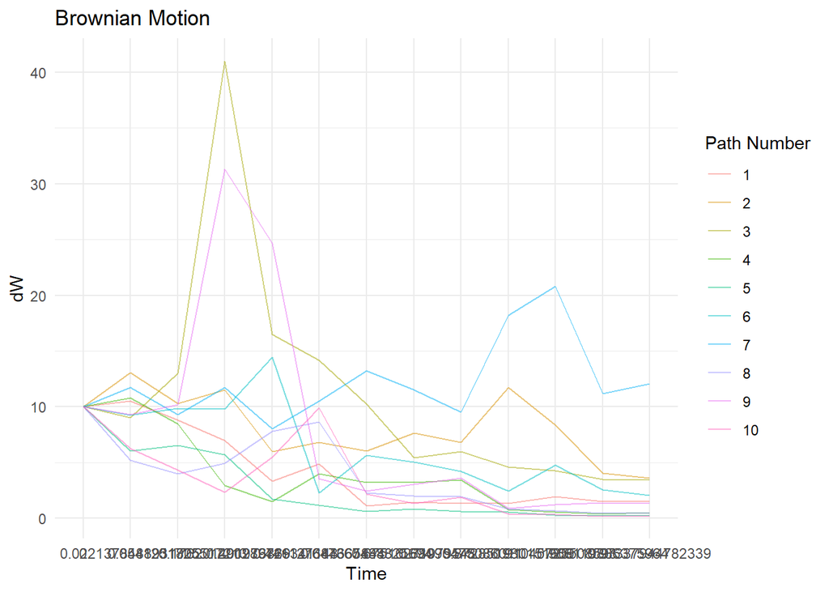

## References

Wikipedia contributors. 2022. “Vasicek Model — Wikipedia, the Free Encyclopedia.” https://en.wikipedia.org/wiki/Vasicek_model.